# Harp 325 Midterm

Use the following data to produce 1 table of summary information and 2-3 graphs.

Notes on the data: the total, professional, and computer_all job groups are available for all four years of data. Focus on these if you want to produce graphs of jobs over time. The individual occupations change from one year to the next, so you will not be able to graph them over time (with the exception of computer programmers). You may, however, filter one year of data and make a bar or point plot for each occupation in that year.

The All variable is measured as total jobs in that category, while Women, Black, Asian, and Latino are the percent of workers who identify with each group. You cannot put All on the same plot as one of these variables, since they are measured in different units.

The goal of the assignment is not only to practice making plots: your task is to present the data in a clear and meaningful way. Points will be deducted, for example, from plots that are hard to read or understand. You are also encouraged to think about how to use colors, labels, and themes effectively. Graphs with multiple groups must have a legend.

Although you will need to filter the data, it does not need to be cleaned up too much in order to be graphed. Don’t overthink it!

```r
rm(list=ls())

data <- read.csv("http://tinyurl.com/dida325midtermdata", stringsAsFactors = F, fileEncoding="UTF-8-BOM")
View(data)
library(dplyr)
library(ggplot2)
```

clean up data to remove NA and insure that i’m not getting NA’s as a result:

```r
#clean up data
data<-na.omit(data)
```

filter by job type and store in separate dataframe:

```r
comp_all <- data %>% filter(job_type == "computer_all")
```

view data:

```r
View(comp_all)
```

plot data for women in cc to see if there’s any specific trend

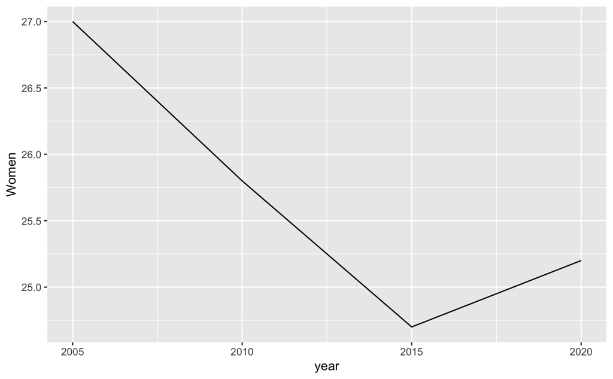

this shows me that 2015 was a bad year for women in cs maybe i should look at other categories to see if that year was also bad

total check

|  | job_type | description | year | All | Women | Black | Asian | Hispanic.Latino |
| --- | --- | --- | --- | --- | --- | --- | --- | --- |
| 1 | total | Total, 16 years and over | 2015 | 148834 | 46.8 | 11.7 | 5.8 | 16.4 |

test total

```r
library(ggplot2)

wide_data <- data %>% select( year,job_type,Women,Asian)

long_data <- wide_data %>%
  #The column titles become the categories in a new column after the reshaping
  #I'm naming this new column Gender
  #The number of students are put in a new values column, which I'm calling Majors
  pivot_longer(-c(year,job_type), names_to = "category", values_to = "percentage")

ggplot(long_data , aes(x = year , y= percentage, group = category, fill=category)) +
  geom_bar(position="dodge", stat = "identity")




#job type stats for women
long_data_w <- long_data %>% filter(category=="Women")
long_data_w <- long_data_w %>% select(-category)

ggplot(long_data_w , aes(x = year , y= percentage, group = job_type, fill=job_type)) +
  geom_bar(position="dodge", stat = "identity")



ggplot(data , aes(x = year , y= Women, group = job_type, fill=job_type)) +
  geom_bar(position="dodge", stat = "identity")





ggplot(data , aes(x = year , y= Women, group = job_type, fill=job_type)) +
  geom_bar(position="dodge", stat = "identity")



?geom_bar
View(data_2015)
```

[output not shown]